# Chutes and Ladders

Joey Stanley

4/21/2019

We tried teaching our little almost-three-year-old *Chutes and Ladders* today. She wasn’t very good at counting tiles. But, as I was sitting there climbing up and sliding down over and over, I wondered what the average number of turns it would take to finish the game. So I decided to take a stab at simulating the game. So here’s a post on a simple simulation of *Chutes and Ladders* that demonstrates nothing about linguistics but rather some of my R skills.

```r
library(tidyverse)
library(ggthemes)
library(scico)
library(readxl)
library(gganimate)
```

## The game

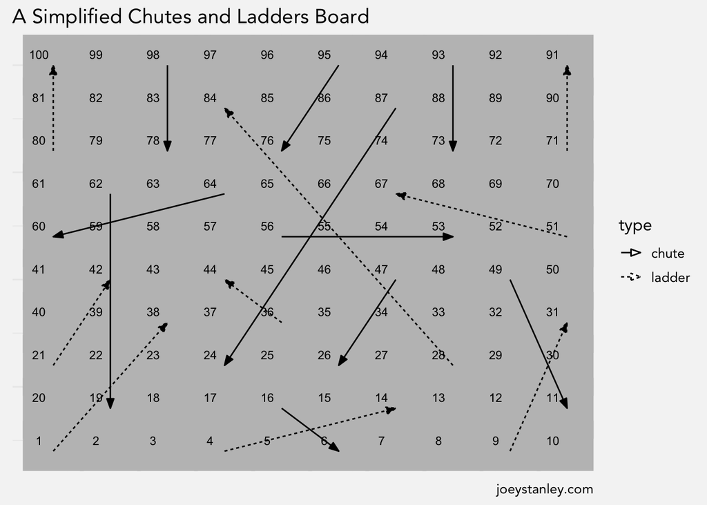

```r
tile_data <- read_excel("chutes_ladders_data.xlsx", sheet = 1)
chutes_and_ladders_data <- readxl::read_excel("chutes_ladders_data.xlsx", sheet = 2) %>%
    rowid_to_column("id") %>%
    gather(position, tile, start, end) %>%
    left_join(tile_data, by = "tile")

ggplot(tile_data, aes(x, y)) +
    geom_point(shape = "square", size = 20, color = "gray75") +
    geom_text(aes(label = tile), size = 3, nudge_x = -0.25, nudge_y = 0.25) +
    labs(title = "A Simplified Chutes and Ladders Board",
         caption = "joeystanley.com") +
    theme(axis.title = element_blank(),
          axis.ticks = element_blank(),
          axis.text  = element_blank(),
          panel.border = element_blank()) +
    geom_path(data = chutes_and_ladders_data, aes(group = id, linetype = type),
              arrow = arrow(angle = 20, length = unit(0.1, "in"), type = "closed"))
```

```r
ggsave("images/basic_board.jpeg", height = 7, width = 7.5, dpi = 300)
```

The game we bought is actually a knock-off (I’m a poor grad student—what do you expect?), but I found an image of the authentic version online so I’ll go with that for this blog post. For simplicity, I’ll just simulate a one-person game.

## The simulation

Simulating the game is relatively straightforward. All you really need is a way to keep track of what tile you’re on, a way to roll the die, and string of if-else statements to simulate the chutes and ladders. The die rolling is pretty simple with the help of `sample`.

```r
sample(6, 1)
```

```
## [1] 2
```

We could wrap that up into a function to make it slightly more transparent too:

```r
roll_die <- function() {
  sample(6, 1)
}
roll_die()
```

```
## [1] 1
```

```r
roll_die()
```

```
## [1] 3
```

```r
roll_die()
```

```
## [1] 5
```

Now, in this game, every time you roll a die, you’ll need to advance your token by that many pieces. I could write a separate `advance_token` function, but with functions this small, I’ll just combine them into one. This time, it’ll take an argument, `spot`, which is the current tile number (from 1 to 100) that you’re on. The function takes this spot, rolls a die, and adds that value to it, returning the tile you’ll land on.

```r
roll_die <- function(spot) {
  spot + sample(6, 1)
}
roll_die(1)
```

```
## [1] 2
```

```r
roll_die(10)
```

```
## [1] 16
```

```r
roll_die(50)
```

```
## [1] 52
```

```r
roll_die(80)
```

```
## [1] 85
```

Awesome. Now with this, it makes for a pretty uneventful game, so we’ll have to simulate the chutes and ladders. I know base R has `switch` syntax, but I’ve never gotten the syntax to work, so I’ll use `case_when` from the `dplyr` package to do this. I’ll of course wrap it up in another function verbosely called `check_for_chute_or_ladder`. Here, I input the start and end points to all the chutes and ladders. So for example, if you land on the very first tile, there’s a ladder that’ll take you to tile 38. If you land on tile 16, you’ll slide down a chute to tile 6. The function will return the new tile you’ll end up on. If you don’t land on any of them, the function will return the same number you sent in.

```r
check_for_chute_or_ladder <- function(spot) {
  case_when(

    # Ladders (9)
    spot ==  1 ~  38,
    spot ==  4 ~  14,
    spot ==  9 ~  31,
    spot == 21 ~  42,
    spot == 28 ~  84,
    spot == 36 ~  44,
    spot == 51 ~  67,
    spot == 71 ~  91,
    spot == 80 ~ 100,

    # Chutes (10)
    spot == 16 ~   6,
    spot == 47 ~  26,
    spot == 49 ~  11,
    spot == 56 ~  53,
    spot == 62 ~  19,
    spot == 64 ~  60,
    spot == 87 ~  24,
    spot == 93 ~  73,
    spot == 95 ~  76,
    spot == 98 ~  78,

    # No change
    TRUE ~ spot)
}
check_for_chute_or_ladder(1)
```

```
## [1] 38
```

```r
check_for_chute_or_ladder(4)
```

```
## [1] 14
```

```r
check_for_chute_or_ladder(5)
```

```
## [1] 5
```

Great. Now we’ve got a full turn. For kicks, I can wrap all this up into yet another function that’ll simulate taking a turn in the game:

```r
set.seed(1)
take_turn <- function(spot) {
  spot %>%
    roll_die() %>%
    check_for_chute_or_ladder()
}
take_turn(1)
```

```
## [1] 3
```

```r
take_turn(3)
```

```
## [1] 6
```

```r
take_turn(6)
```

```
## [1] 10
```

```r
take_turn(10)
```

```
## [1] 6
```

```r
take_turn(6)
```

```
## [1] 8
```

So as it turns out, these are all the functions I need to simulate an entire game. But, the way it’s set up now, I have to run each turn one at a time, check the output, and run it again. It would be better if I could automate the whole thing and save the results into a dataframe or something.

So I’ve created the larger `simulate_game` function below. When I run this function, it’ll simulate an entire (1-player) game. First, it’ll create a mostly empty data frame that will be populated as the turns advance. I know that some programming languages are slow if you try to append rows to a dataframe with each iteration of a loop (SIDENOTE: I think Perl doesn’t care, and I miss that…), so I wanted to declare make sure there was room for a full game before we do anything else. Also, in theory, the game could last forever because of looping chutes and ladders, so I made it large enough to handle a game with 1000 turns—probably way too many for this, but I wanted to make sure.(SIDENOTE: I started with 100-turns, but that actually wasn’t enough for some simulations!) Anyway, in that dataframe, I have columns for the turn number, what the dice roll was (those are all predetermined), where you landed, whether it has a chute or a ladder, and finally, where you ended up after travelling on that chute or ladder.

I’ve never done a simulation in R before, so I don’t know what the protocol is for looping through something an unknown number of times, so I did this whole `while(keep_playing)` thing. The `keep_playing` object is initially true, and at the end of each iteration, I check to see if we’ve gotten to 100; if so, I’ll set that to false, which’ll kill the loop. However, I wanted some sort of iterating number (like in a `for` loop), so I added `i` myself.(SIDENOTE: I tried just looping through the `turn_num` column, but I couldn’t get the loop to stop after hitting 100.).

Okay, so then inside that loop, there are several main chunks. Most of it is fluff for handling the data and keeping track of stuff and the actual game portion is just two lines in the middle.

1. First, if it’s the first iteration of the loop, set the start tile number to 0. Otherwise, set it to wherever we ended up last time.
2. Then, I add the dice roll to to the start tile to get the (potentially) temporary `land` tile. I then send that number off to `check_for_chute_or_ladder` and get the actual `end` tile.
3. I then do another conditional to tell whether I had a chute or ladder. In theory, I should just be able to tell that with the `check_for_chute_or_ladder` function, but I’m not sure how to return two values at once in R like I can with Perl.
4. Finally, I’ll do one more conditional to see if we’ve reached tile 100. If not, go on to the next iteration of the loop. If so, we’re done.

After the looping is done, we’ve completed a game. Remember that I started by declaring enough space for 1000 turns. I don’t need all the extra rolls, so just before I return the dataframe with all the game information, filter out the rolls that didn’t happen.

```r
simulate_game <- function(game_num = 0) {

  # Declare space for the full game.
  n <- 1000
  turns <- tibble(turn_num = 1:n,
                  start    = NA,
                  roll     = sample(6, n, replace = TRUE),
                  land     = NA,
                  chute_or_ladder = NA,
                  end      = NA)

  # Loop until the game is over
  i <- 1
  keep_playing <- TRUE
  while(keep_playing) {

    # Step 1: Start at zero
    if (i == 1) {
      turns$start[[i]] <- 0

    # Otherwise, start where the last turn ended.
    } else {
      turns$start[[i]] <- turns$end[[i - 1]]
    }

    # Step 2: This is where the game actually happens.
    # Add dice roll to the start tile
    turns$land[[i]] <- turns$start[[i]] + turns$roll[[i]]
    # Check for chute or ladder
    turns$end[[i]] <- check_for_chute_or_ladder(turns$land[[i]])

    # Step 3: Keep track of whether I had a chute or ladder.
    if (turns$land[[i]] > turns$end[[i]]) {
      turns$chute_or_ladder[[i]] <- "ladder"
    } else if (turns$land[[i]] < turns$end[[i]]) {
      turns$chute_or_ladder[[i]] <- "chute"
    } else {
      turns$chute_or_ladder[[i]] <- NA
    }

    # Step 4: Check if it's game over.
    if (turns$end[[i]] >= 100) {
      keep_playing <- FALSE
    } else {
      i <- i + 1
    }
  }

  turns %>%
    filter(turn_num <= i) %>%
    return()
}
set.seed(1)
simulate_game()
```

```
## # A tibble: 17 x 6
##    turn_num start  roll  land chute_or_ladder   end
##       <int> <dbl> <int> <dbl> <chr>           <dbl>
##  1        1     0     2     2 <NA>                2
##  2        2     2     3     5 <NA>                5
##  3        3     5     4     9 chute              31
##  4        4    31     6    37 <NA>               37
##  5        5    37     2    39 <NA>               39
##  6        6    39     6    45 <NA>               45
##  7        7    45     6    51 chute              67
##  8        8    67     4    71 chute              91
##  9        9    91     4    95 ladder             76
## 10       10    76     1    77 <NA>               77
## 11       11    77     2    79 <NA>               79
## 12       12    79     2    81 <NA>               81
## 13       13    81     5    86 <NA>               86
## 14       14    86     3    89 <NA>               89
## 15       15    89     5    94 <NA>               94
## 16       16    94     3    97 <NA>               97
## 17       17    97     5   102 <NA>              102
```

Hooray! A complete game. This one appears to have been completed in 17 moves after hitting three chutes and one ladder.

# Simulating lots of games

Okay, so I’ve got the code for simulating a game of *Chutes and Ladders* and in the example above, I finished a game in just 17 moves. Is that average or did I finish a bit sooner than normal?

To answer this question, I’ll just run the `simulate_game` function a whole bunch of times and then see if I can see some generalizations. I’ll accomplish this with `map` from the `purrr` package.

```r
set.seed(1)
games <- tibble(game_num = 1:1000) %>%
  mutate(game = map(game_num, simulate_game)) %>%
  unnest()
games
```

```
## # A tibble: 36,856 x 7
##    game_num turn_num start  roll  land chute_or_ladder   end
##       <int>    <int> <dbl> <int> <dbl> <chr>           <dbl>
##  1        1        1     0     2     2 <NA>                2
##  2        1        2     2     3     5 <NA>                5
##  3        1        3     5     4     9 chute              31
##  4        1        4    31     6    37 <NA>               37
##  5        1        5    37     2    39 <NA>               39
##  6        1        6    39     6    45 <NA>               45
##  7        1        7    45     6    51 chute              67
##  8        1        8    67     4    71 chute              91
##  9        1        9    91     4    95 ladder             76
## 10        1       10    76     1    77 <NA>               77
## # … with 36,846 more rows
```

```r
games_summary <- games %>%
  group_by(game_num) %>%
  summarize(turns = max(turn_num),
            n_chutes  = sum(chute_or_ladder == "chute", na.rm = TRUE),
            n_ladders = sum(chute_or_ladder == "ladder", na.rm = TRUE))
games_summary
```

```
## # A tibble: 1,000 x 4
##    game_num turns n_chutes n_ladders
##       <int> <dbl>    <int>     <int>
##  1        1    17        3         1
##  2        2     9        2         0
##  3        3    29        6         4
##  4        4    44        5         5
##  5        5    47        4         7
##  6        6    96        6        14
##  7        7    26        4         4
##  8        8    35        0         3
##  9        9    46        5         7
## 10       10    39        2         6
## # … with 990 more rows
```

Looks like there’s a lot of variation. Game 1 was finished in 17 moves, but Game 2 was done in just 9. Meanwhile game 6 took 96 moves to finish. Yikes. With just plain ol’ `summary`, I can now just get some information about what an average game was like.

```r
summary(games_summary)
```

```
##     game_num          turns           n_chutes        n_ladders
##  Min.   :   1.0   Min.   :  7.00   Min.   : 0.000   Min.   : 0.000
##  1st Qu.: 250.8   1st Qu.: 19.00   1st Qu.: 2.000   1st Qu.: 1.000
##  Median : 500.5   Median : 30.00   Median : 3.000   Median : 3.000
##  Mean   : 500.5   Mean   : 36.86   Mean   : 3.179   Mean   : 4.114
##  3rd Qu.: 750.2   3rd Qu.: 48.00   3rd Qu.: 4.000   3rd Qu.: 6.000
##  Max.   :1000.0   Max.   :197.00   Max.   :15.000   Max.   :31.000
```

So it appears that it took about 37 turns on average to make it to tile 100. So my first game in 17 turns was pretty short—in the top 25%. But now the shortest one took just 7 moves. However, the game theoretically could go on forever, and indeed one game took a whopping 197 turns to finish! I don’t think my two-year-old would appreciate that so much. Let’s visualize that distribution:

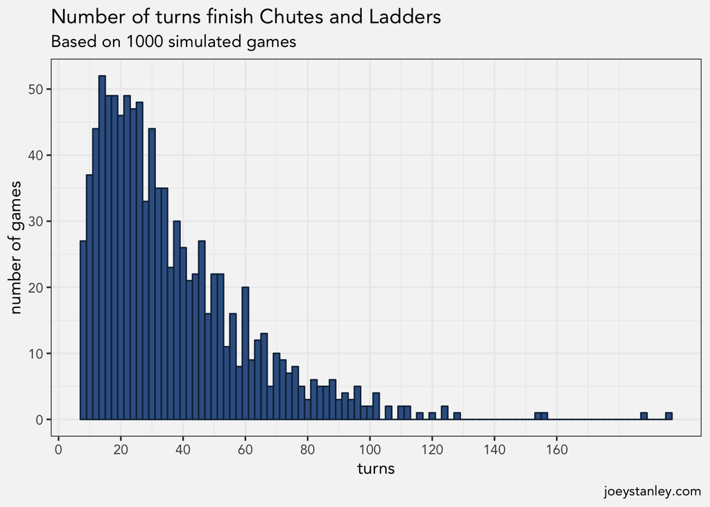

```r
ggplot(games_summary, aes(turns)) +
    geom_histogram(binwidth = 2, fill = "#376092", color = "#132A45") +
    scale_x_continuous(breaks = seq(0, 160, 20)) +
    scale_y_continuous(breaks = seq(0, 60, 10)) +
    labs(title = "Number of turns finish Chutes and Ladders",
         subtitle = "Based on 1000 simulated games",
         caption = "joeystanley.com",
         y = "number of games")
```

So, most of the time, I’ll finish my game in about 15–30 moves. I guess that’s not too bad.

Obviously the most exciting part of the game is getting to travel on some chutes or ladders. How many times did I do that on average? The summary statistics above suggest maybe 3 or 4, but the data is pretty skewed. Let’s look at some visuals.

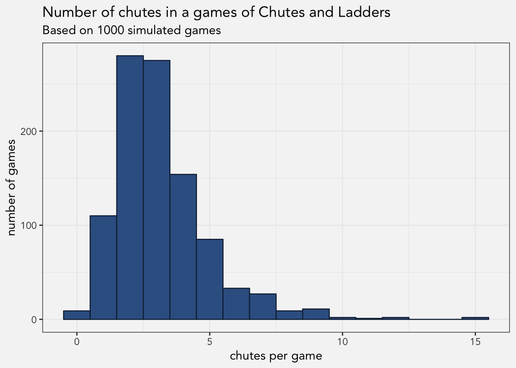

```r
ggplot(games_summary, aes(n_chutes)) +
    geom_histogram(binwidth = 1, fill = "#376092", color = "#132A45") +
    labs(title = "Number of chutes in a games of Chutes and Ladders",
         subtitle = "Based on 1000 simulated games",
         x = "chutes per game",
         y = "number of games")
```

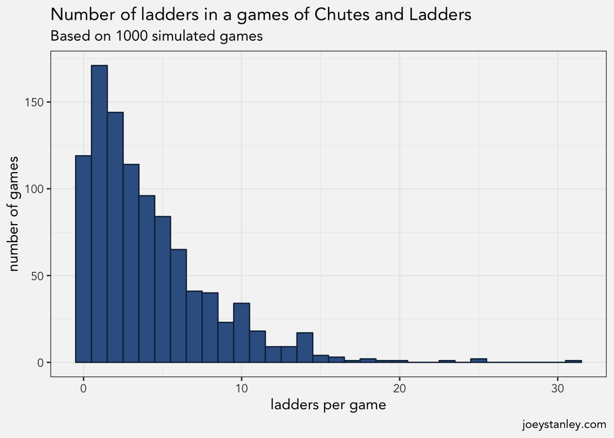

```r
ggplot(games_summary, aes(n_ladders)) +
    geom_histogram(binwidth = 1, fill = "#376092", color = "#132A45") +
    labs(title = "Number of ladders in a games of Chutes and Ladders",
         subtitle = "Based on 1000 simulated games",
         caption = "joeystanley.com",
         x = "ladders per game",
         y = "number of games")
```

So I guess that answered the questions I had. I’m typically going to finish the game in about 20–30 moves, and I’ll have perhaps a half dozen eventful rolls with a chute or a ladder.

So what was up with that one game with 197 turns?? Here’s an animation of how that game went down.

```r
one_long_game <- games %>%
    group_by(game_num) %>%
    filter(max(turn_num) == 197) %>%
    ungroup() %>%
    select(-game_num) %>%
    gather(timing, tile, start, land, end) %>%
    mutate(timing = factor(timing, levels = c("start", "land", "end"))) %>%
    arrange(turn_num, timing) %>%
    filter(!(is.na(chute_or_ladder) & timing == "land")) %>%
    left_join(tile_data, by = "tile") %>%
    rowid_to_column("t") %>%
    print()
```

```
## # A tibble: 440 x 8
##        t turn_num  roll chute_or_ladder timing  tile     x     y
##    <int>    <int> <int> <chr>           <fct>  <dbl> <dbl> <dbl>
##  1     1        1     5 <NA>            start      0    NA    NA
##  2     2        1     5 <NA>            end        5     5     1
##  3     3        2     3 <NA>            start      5     5     1
##  4     4        2     3 <NA>            end        8     8     1
##  5     5        3     5 <NA>            start      8     8     1
##  6     6        3     5 <NA>            end       13     8     2
##  7     7        4     2 <NA>            start     13     8     2
##  8     8        4     2 <NA>            end       15     6     2
##  9     9        5     4 <NA>            start     15     6     2
## 10    10        5     4 <NA>            end       19     2     2
## # … with 430 more rows
```

```r
long_game_animation <- ggplot(tile_data, aes(x, y)) +
    geom_point(shape = "square", size = 11.5, color = "white") +
    geom_text(aes(label = tile), size = 3, nudge_x = -0.25, nudge_y = 0.25) +
    geom_point(data = one_long_game, size = 4) +
    scale_color_scico(palette = "lajolla", direction = -1) +
    coord_fixed(ratio = 1) +
    labs(title = "A 197-turn game of Chutes and Ladders",
         subtitle = 'Turn {closest_state} of {nframes}',
         caption = "joeystanley.com") +
    theme(axis.title = element_blank(),
          axis.ticks = element_blank(),
          axis.text  = element_blank(),
          panel.border = element_blank()) +
    geom_path(data = chutes_and_ladders_data, aes(group = id, linetype = type),
              arrow = arrow(angle = 20, length = unit(0.1, "in"), type = "closed")) +
    transition_time(t) +
    ease_aes('cubic-in-out')
# animate(long_game_animation, nframe = 2000)
```

```r
state_lengths <- one_long_game %>%
    head(n = 50) %>%
    group_by(turn_num) %>%
    count() %>%
    print()
```

```
## # A tibble: 24 x 2
## # Groups:   turn_num [24]
##    turn_num     n
##       <int> <int>
##  1        1     2
##  2        2     2
##  3        3     2
##  4        4     2
##  5        5     2
##  6        6     2
##  7        7     2
##  8        8     2
##  9        9     2
## 10       10     2
## # … with 14 more rows
```

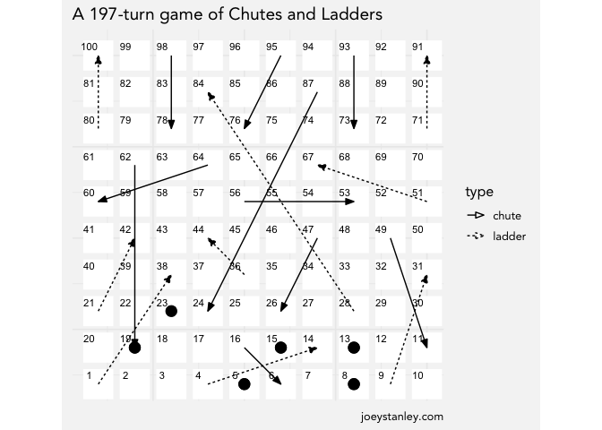

```r
long_game_animation <- ggplot(tile_data, aes(x, y)) +
    geom_point(shape = "square", size = 11.5, color = "white") +
    geom_text(aes(label = tile), size = 3, nudge_x = -0.25, nudge_y = 0.25) +
    geom_point(data = one_long_game, size = 4) +
    scale_color_scico(palette = "lajolla", direction = -1) +
    coord_fixed(ratio = 1) +
    labs(title = "A 197-turn game of Chutes and Ladders",
         #subtitle = 'Turn {closest_state} of 197',
         caption = "joeystanley.com") +
    theme(axis.title = element_blank(),
          axis.ticks = element_blank(),
          axis.text  = element_blank(),
          panel.border = element_blank()) +
    geom_path(data = chutes_and_ladders_data, aes(group = id, linetype = type),
              arrow = arrow(angle = 20, length = unit(0.1, "in"), type = "closed")) +
    #transition_states(t, wrap = FALSE) +
    transition_time(t) +
    ease_aes('cubic-in-out')
animate(long_game_animation, nframe = 20)
```

```r
library(glue)
```

[figure not shown]

```r
ggplot(iris, aes(x = Petal.Width, y = Petal.Length)) +
    labs(title = 'Now showing {closest_state}') +
    geom_point() +
    transition_states(Species,
                      transition_length = 2,
                      state_length = 1)
```

# Most likely tiles

So of course the next question you might want to ask is what tiles are you most likely to be on. Well it’s not going to be an even distribution because of the chutes and ladders throwing you all over the place. Here’s a simple plot that shows how often the simulation ended a turn on a particular tile

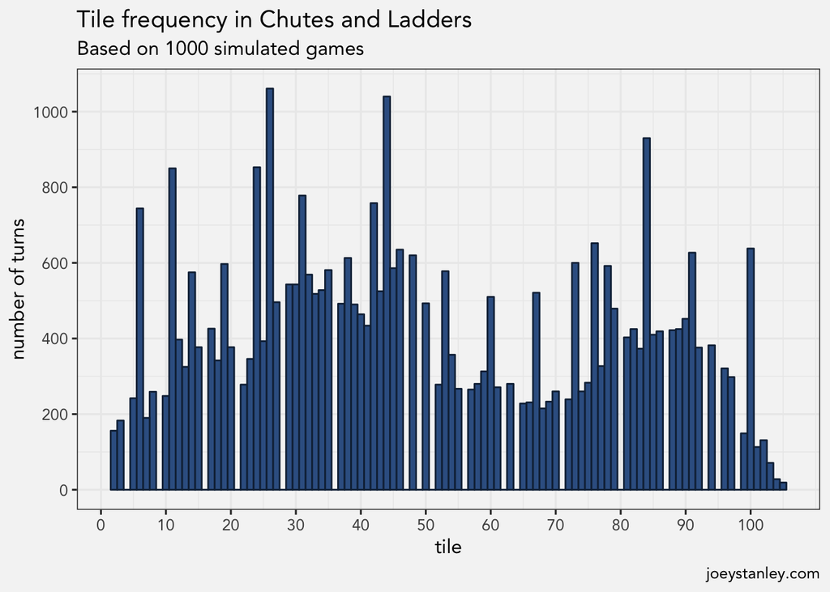

```r
ggplot(games, aes(end)) +
    geom_histogram(binwidth = 1, fill = "#376092", color = "#132A45") +
    scale_x_continuous(breaks = seq(0, 100, 10)) +
    scale_y_continuous(breaks = seq(0, 1000, 200)) +
    labs(title = "Tile frequency in Chutes and Ladders",
         subtitle = "Based on 1000 simulated games",
         caption = "joeystanley.com",
         x = "tile",
         y = "number of turns")
```

Now obviously the large spikes are the ends of ladders and chutes, so you’re twice as likely to end up there, either because you took the chute/ladder or because you ended up there by approaching it from a previous tile. But what is interesting to me is the gradual ebb and flow: you’ll spend more time in the 20–50 range and in the 80s, but less time in the 50–70 range. Cool.

Here’s a different way of looking at that data in a way that more closely matches the board.

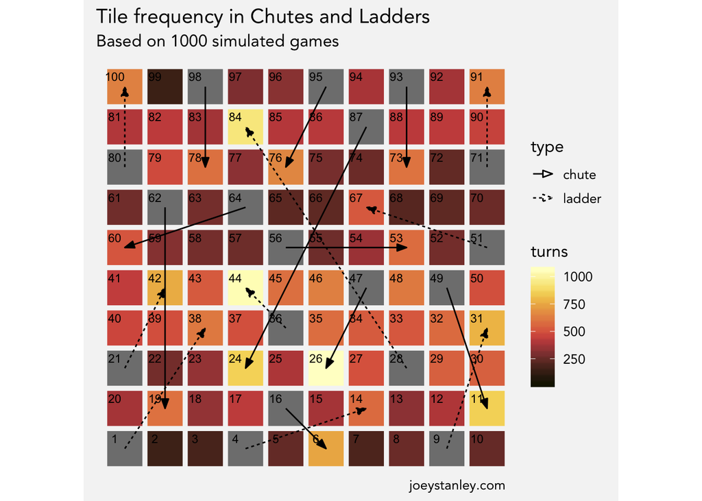

```r
tile_freq <- games %>%
    rename(tile = end) %>%
    count(tile) %>%
    full_join(tile_data, by = "tile")

ggplot(tile_freq, aes(x, y)) +
    geom_point(aes(color = n), shape = "square", size = 11.5) +
    geom_text(aes(label = tile), size = 3, nudge_x = -0.25, nudge_y = 0.25) +
    geom_path(data = chutes_and_ladders_data, aes(group = id, linetype = type),
              arrow = arrow(angle = 20, length = unit(0.1, "in"), type = "closed")) +
    scico::scale_color_scico(name = "turns", palette = "lajolla", direction = -1) +
    coord_fixed(ratio = 1) +
    labs(title = "Tile frequency in Chutes and Ladders",
         subtitle = "Based on 1000 simulated games",
         caption = "joeystanley.com") +
    theme(axis.title = element_blank(),
          axis.ticks = element_blank(),
          axis.text  = element_blank(),
          panel.grid = element_blank(),
          panel.border = element_blank())
```

# Changing the game

Okay so now the question is what happens if you change the game up. If I take away a ladder, how does that affect the game? It probably depends on the length, but let’s try taking out the longest ones and see what happens.

To do this, I’ll create a new version of `check_for_chute_and_ladder` only the longest ladder is commented out. I’ll then rerun the simulation and compare the results.

```r
check_for_chute_or_ladder <- function(spot) {
  case_when(

    # Ladders (9)
    spot ==  1 ~  38,
    spot ==  4 ~  14,
    spot ==  9 ~  31,
    spot == 21 ~  42,
    #spot == 28 ~  84,
    spot == 36 ~  44,
    spot == 51 ~  67,
    spot == 71 ~  91,
    spot == 80 ~ 100,

    # Chutes (10)
    spot == 16 ~   6,
    spot == 47 ~  26,
    spot == 49 ~  11,
    spot == 56 ~  53,
    spot == 62 ~  19,
    spot == 64 ~  60,
    spot == 87 ~  24,
    spot == 93 ~  73,
    spot == 95 ~  76,
    spot == 98 ~  78,

    # No change
    TRUE ~ spot)
}
set.seed(1)
games_without_longest_ladder <- tibble(game_num = 1:1000) %>%
  mutate(game = map(game_num, simulate_game)) %>%
  unnest()
```

Now I’ll do the same thing without the longest chute.

```r
check_for_chute_or_ladder <- function(spot) {
  case_when(

    # Ladders (9)
    spot ==  1 ~  38,
    spot ==  4 ~  14,
    spot ==  9 ~  31,
    spot == 21 ~  42,
    spot == 28 ~  84,
    spot == 36 ~  44,
    spot == 51 ~  67,
    spot == 71 ~  91,
    spot == 80 ~ 100,

    # Chutes (10)
    spot == 16 ~   6,
    spot == 47 ~  26,
    spot == 49 ~  11,
    spot == 56 ~  53,
    spot == 62 ~  19,
    spot == 64 ~  60,
    #spot == 87 ~  24,
    spot == 93 ~  73,
    spot == 95 ~  76,
    spot == 98 ~  78,

    # No change
    TRUE ~ spot)
}
set.seed(1)
games_without_longest_chute <- tibble(game_num = 1:1000) %>%
  mutate(game = map(game_num, simulate_game)) %>%
  unnest()
```

Now I’ll combine all this game data.

```r
modified_games <- bind_rows(list(original = games,
                                 `w/o longest ladder`  = games_without_longest_ladder,
                                 `w/o longest chute`   = games_without_longest_chute),
                            .id = "modification") %>%
    group_by(modification, game_num) %>%
    summarize(turns = max(turn_num),
              n_chutes  = sum(chute_or_ladder == "chute", na.rm = TRUE),
              n_ladders = sum(chute_or_ladder == "ladder", na.rm = TRUE))
modified_games
```

```
## # A tibble: 3,000 x 5
## # Groups:   modification [3]
##    modification game_num turns n_chutes n_ladders
##    <chr>           <int> <dbl>    <int>     <int>
##  1 original            1    17        3         1
##  2 original            2     9        2         0
##  3 original            3    29        6         4
##  4 original            4    44        5         5
##  5 original            5    47        4         7
##  6 original            6    96        6        14
##  7 original            7    26        4         4
##  8 original            8    35        0         3
##  9 original            9    46        5         7
## 10 original           10    39        2         6
## # … with 2,990 more rows
```

And now I’ll plot their distributions all overlayed on top of each other.

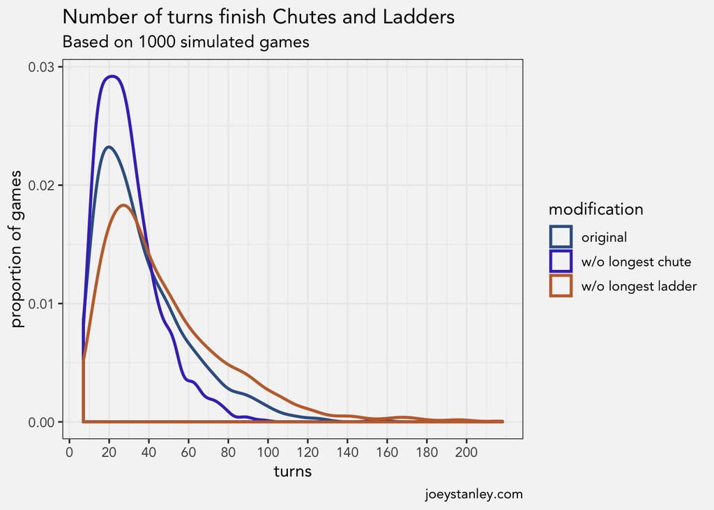

```r
ggplot(modified_games, aes(turns, color = modification)) +
    geom_density(size = 1) +
    scale_x_continuous(breaks = seq(0, 200, 20)) +
    labs(title = "Number of turns finish Chutes and Ladders",
         subtitle = "Based on 1000 simulated games",
         caption = "joeystanley.com",
         y = "proportion of games") +
    scale_color_manual(values = c("#376092", "#4237C4", "#C46D37"))
```